# Demographics and reproductive biology of H. schistosus from bycatch on the west coast of India

Analysis for Manuscript

# 1 Demographics of *H. schistosus* across time

## 1.1 Sample size

| Species | N |
| --- | --- |
| Hydrophis curtus | 282 |
| Hydrophis schistosus | 967 |

| Gear.Type | n | haul.hours |
| --- | --- | --- |
| GillNet | 441 | 588.2133 |
| Rampan | 47 | 194.4500 |
| Trawler | 78 | 298.6600 |

## 1.2 Age structure

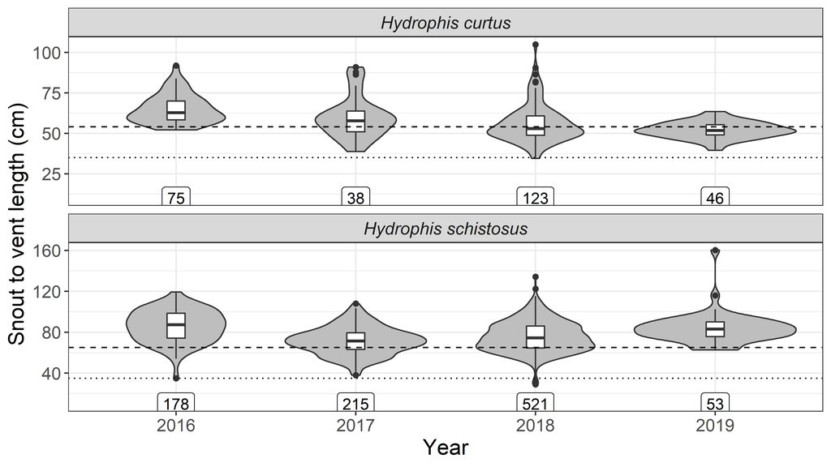

**Variable type: numeric**

| skim_variable | Species | Class | n_missing | complete_rate | mean | sd | p0 | p25 | p50 | p75 | p100 |
| --- | --- | --- | --- | --- | --- | --- | --- | --- | --- | --- | --- |
| prop.age | Hydrophis curtus | Adult | 0 | 1 | 0.43 | 0.31 | 0.17 | 0.28 | 0.33 | 0.49 | 0.88 |
| prop.age | Hydrophis curtus | Juvenile | 0 | 1 | 0.57 | 0.31 | 0.12 | 0.50 | 0.66 | 0.72 | 0.83 |
| prop.age | Hydrophis curtus | Neonate | 0 | 1 | 0.00 | 0.01 | 0.00 | 0.00 | 0.00 | 0.00 | 0.02 |
| prop.age | Hydrophis schistosus | Adult | 0 | 1 | 0.88 | 0.09 | 0.79 | 0.84 | 0.87 | 0.91 | 1.00 |
| prop.age | Hydrophis schistosus | Juvenile | 0 | 1 | 0.10 | 0.09 | 0.00 | 0.06 | 0.10 | 0.15 | 0.21 |
| prop.age | Hydrophis schistosus | Neonate | 0 | 1 | 0.01 | 0.02 | 0.00 | 0.00 | 0.01 | 0.02 | 0.04 |

| Species | Class | estimate1 | estimate2 | estimate3 | statistic | p.value |
| --- | --- | --- | --- | --- | --- | --- |
| Hydrophis curtus | Adult | 0.8750000 | 0.3125000 | 0.3551402 | 9.2546983 | 0.0097807 |
| Hydrophis curtus | Juvenile | 0.1250000 | 0.6875000 | 0.6261682 | 8.8509715 | 0.0119684 |
| Hydrophis curtus | Neonate | 0.0000000 | 0.0000000 | 0.0186916 | 0.7579762 | 0.6845538 |
| Hydrophis schistosus | Adult | 0.8846154 | 0.7894737 | 0.8613445 | 5.9949721 | 0.0499124 |
| Hydrophis schistosus | Juvenile | 0.0769231 | 0.2105263 | 0.1239496 | 9.7219255 | 0.0077430 |
| Hydrophis schistosus | Neonate | 0.0384615 | 0.0000000 | 0.0147059 | 4.6191397 | 0.0993040 |

| Species | Sum Sq | Df | F value | Pr(>F) |
| --- | --- | --- | --- | --- |
| Hydrophis schistosus | 9866.294 | 2 | 21.86203 | 0.00e+00 |
| Hydrophis schistosus | 168785.548 | 748 | NA | NA |
| Hydrophis curtus | 2641.334 | 2 | 10.07170 | 7.05e-05 |
| Hydrophis curtus | 24258.408 | 185 | NA | NA |

GLM shows significance but how do you interpret these results?

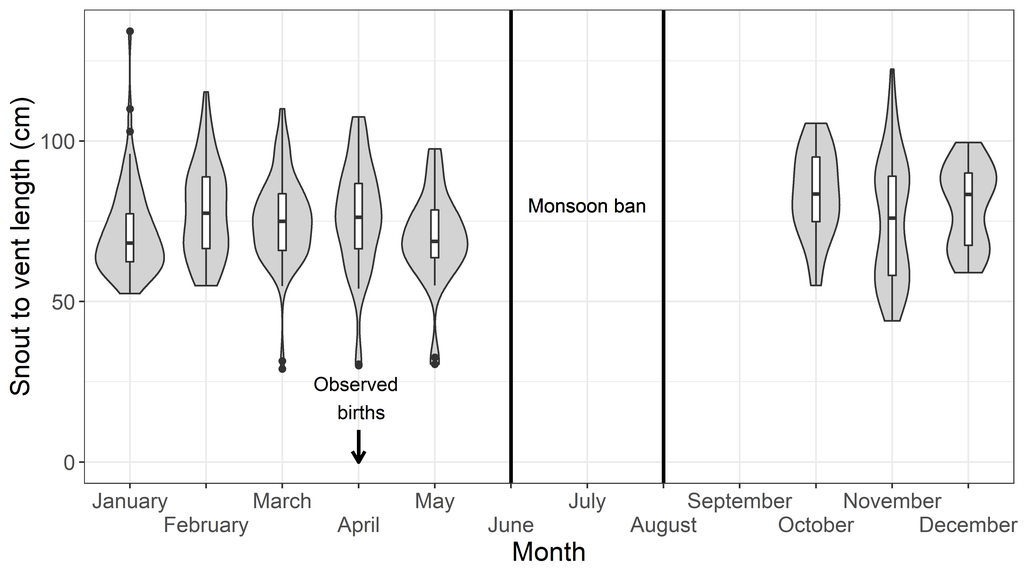

Proportion of neonates increases in March to May. Birth and neonates were observed around the same time.

- GLM testing change in proportion of SVL < 40 over months
- Other ways to test age structure?

| Species | January | February | March | April | May | October | November | December |
| --- | --- | --- | --- | --- | --- | --- | --- | --- |
| Hydrophis curtus | 0 | 0 | 0.50 | NA | NA | 0 | 0.0769231 | 0 |
| Hydrophis schistosus | 0 | 0 | 0.02 | 0.05 | 0.0555556 | 0 | 0.0000000 | 0 |

## 1.3 Sex ratios

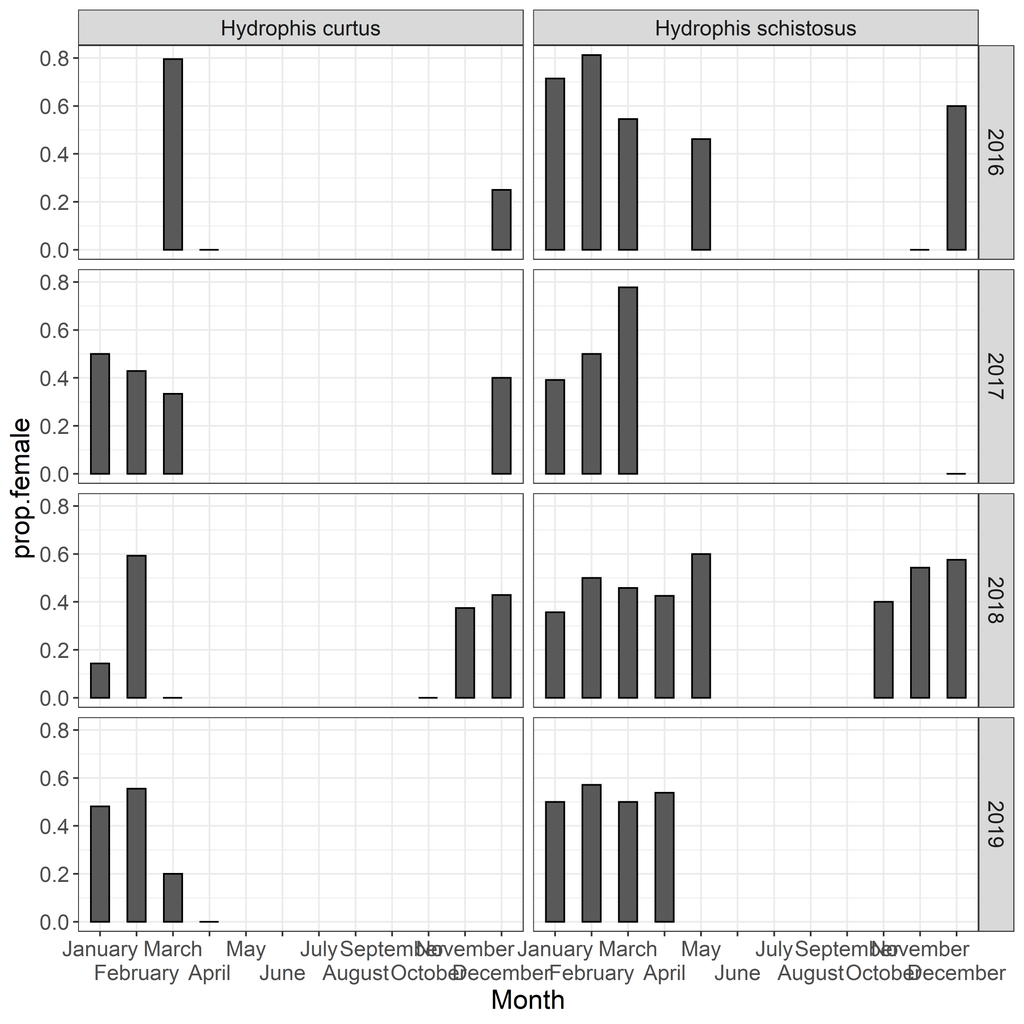

Proportion of females to entire population stays constant over the sampling period.

| Species | females | N |
| --- | --- | --- |
| Hydrophis curtus | 102 | 212 |
| Hydrophis schistosus | 304 | 618 |

| Species | estimate | statistic | p.value | parameter | conf.low | conf.high | method | alternative |
| --- | --- | --- | --- | --- | --- | --- | --- | --- |
| Hydrophis curtus | 0.4811321 | 0.2311321 | 0.6306857 | 1 | 0.4125066 | 0.5504525 | 1-sample proportions test with continuity correction | two.sided |
| Hydrophis schistosus | 0.4919094 | 0.1310680 | 0.7173273 | 1 | 0.4518628 | 0.5320580 | 1-sample proportions test with continuity correction | two.sided |

Sex ratio is not different from 0.5 p = 0.71

# 2 Observed reproductive cycle of *H. schistosus*

| Gravid | n | N | prop.gravid |
| --- | --- | --- | --- |
| Yes | 88 | 967 | 0.0910031 |

| Year | Yes |
| --- | --- |
| 2016 | 1 |
| 2018 | 75 |
| 2019 | 12 |

Proper sampling was only conducted in 2018/19 and hence only this period is used for analysis of reproductive cycles.

```
## # A tibble: 8 x 4
##   Month        N gravid prop.gravid
##   <fct>    <int>  <int>       <dbl>
## 1 January    102     12      0.118
## 2 February   134     34      0.254
## 3 March      129     24      0.186
## 4 April       54      7      0.130
## 5 May         36      1      0.0278
## 6 October     16      0      0
## 7 November    69      3      0.0435
## 8 December    34      6      0.176
```

Describing change in the relative proportions of gravid females across months and years of sampling.

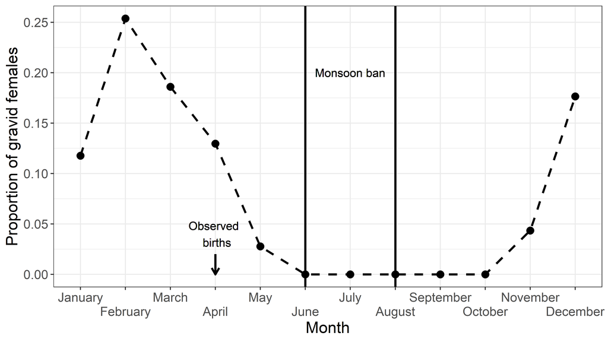

Pregnancy from Novemeber to May. Peak in Feb. Observed two live births in April.

- Anova/GLM with change in proportion of gravid females over time.

# 3 Development of embryos and eggs

## 3.1 Sample size

| n.mothers | n.embryos |
| --- | --- |
| 29 | 235 |

## 3.2 Summary

**Variable type: numeric**

| skim_variable | n_missing | complete_rate | mean | sd | p0 | p25 | p50 | p75 | p100 |
| --- | --- | --- | --- | --- | --- | --- | --- | --- | --- |
| Egg.Length..mm. | 80 | 0.66 | 39.71 | 11.72 | 2.23 | 31.66 | 37.82 | 47.54 | 73.98 |
| Egg.Width..mm. | 80 | 0.66 | 32.23 | 9.01 | 2.02 | 25.56 | 33.72 | 37.64 | 53.09 |
| Egg.Weigth..g. | 51 | 0.78 | 14.30 | 5.45 | 4.23 | 10.75 | 14.00 | 17.25 | 31.00 |
| Snout.to.Vent..cm. | 111 | 0.53 | 17.72 | 5.24 | 6.30 | 14.38 | 16.40 | 21.07 | 30.40 |
| Embryo.Weight..g. | 66 | 0.72 | 4.83 | 6.28 | 0.00 | 0.00 | 3.00 | 8.00 | 20.44 |

**Variable type: numeric**

| skim_variable | n_missing | complete_rate | mean | sd | p0 | p25 | p50 | p75 | p100 |
| --- | --- | --- | --- | --- | --- | --- | --- | --- | --- |
| prop.female | 0 | 1 | 0.56 | 0.32 | 0 | 0.35 | 0.5 | 0.78 | 1 |

[output not shown]

| estimate | statistic | p.value | parameter | conf.low | conf.high |
| --- | --- | --- | --- | --- | --- |
| 0.5180723 | 0.1506024 | 0.6979603 | 1 | 0.4395567 | 0.5957383 |

The sex ratio in clutches is not significantly different from 0.5.

## 3.3 Infertility

| Embryo | n | N | rate |
| --- | --- | --- | --- |
| Absent | 5 | 235 | 2.12766 |
| Present | 230 | 235 | 97.87234 |

## 3.4 Matrotrophy

Do female *H. schistosus* expend energy in the development of embryos? or Are the eggs formed and yolk only provides nourishment?

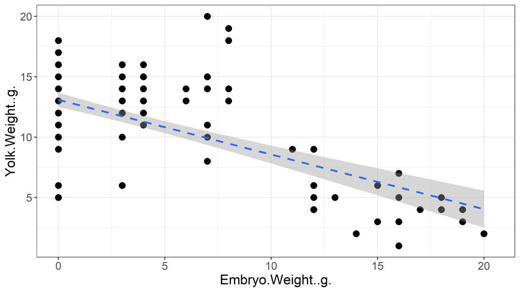

| term | estimate | std.error | statistic | p.value | r.squared |
| --- | --- | --- | --- | --- | --- |
| (Intercept) | 13.0905565 | 0.2965229 | 44.14687 | 0 | 0.4071222 |
| Embryo.Weight..g. | -0.4526283 | 0.0450509 | -10.04705 | 0 | 0.4071222 |

Yolk weight decreases as embryo weight increases.

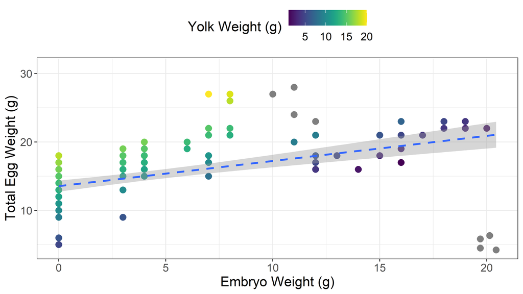

| term | estimate | std.error | statistic | p.value | r.squared |
| --- | --- | --- | --- | --- | --- |
| (Intercept) | 13.5441434 | 0.4114909 | 32.91481 | 0 | 0.2188866 |
| Embryo.Weight..g. | 0.3676922 | 0.0557912 | 6.59050 | 0 | 0.2188866 |

Egg weight increases as embryo weight increases

Decrease of fat bodies as embryos develop indicates matrotrophic nutrition.

- Photos of females dissected ordered according to embryo dev stage

# 4 Reproductive effort

## 4.1 Increase in clutch size with female age

Does the amount of enery expended by female *H. schistosus* reduce with age?

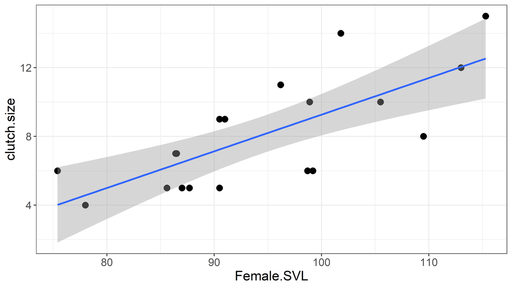

| term | estimate | std.error | statistic | p.value | r.squared |
| --- | --- | --- | --- | --- | --- |
| (Intercept) | -12.0816516 | 4.4876375 | -2.692208 | 0.0154238 | 0.5466726 |
| Female.SVL | 0.2134755 | 0.0471483 | 4.527747 | 0.0002976 | 0.5466726 |

The number of eggs borne by females increases with age (SVL).

## 4.2 Change in overall reproductive effort with age

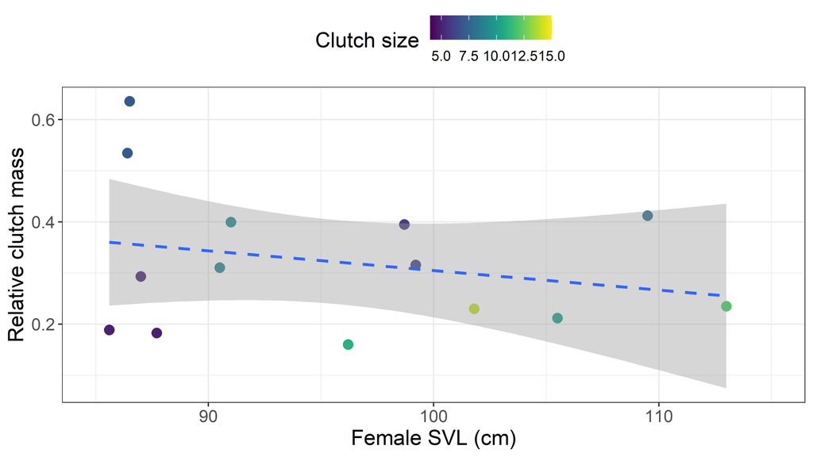

| term | estimate | std.error | statistic | p.value | r.squared |
| --- | --- | --- | --- | --- | --- |
| (Intercept) | 0.6886163 | 0.4077131 | 1.6889727 | 0.1170168 | 0.063695 |
| Female.SVL | -0.0038362 | 0.0042458 | -0.9035133 | 0.3840327 | 0.063695 |

The overall reproductive effort **does not change** with female age.

## 4.3 Change in reproductive effort per embryo with female age

Does the effort per embryo change with female age?

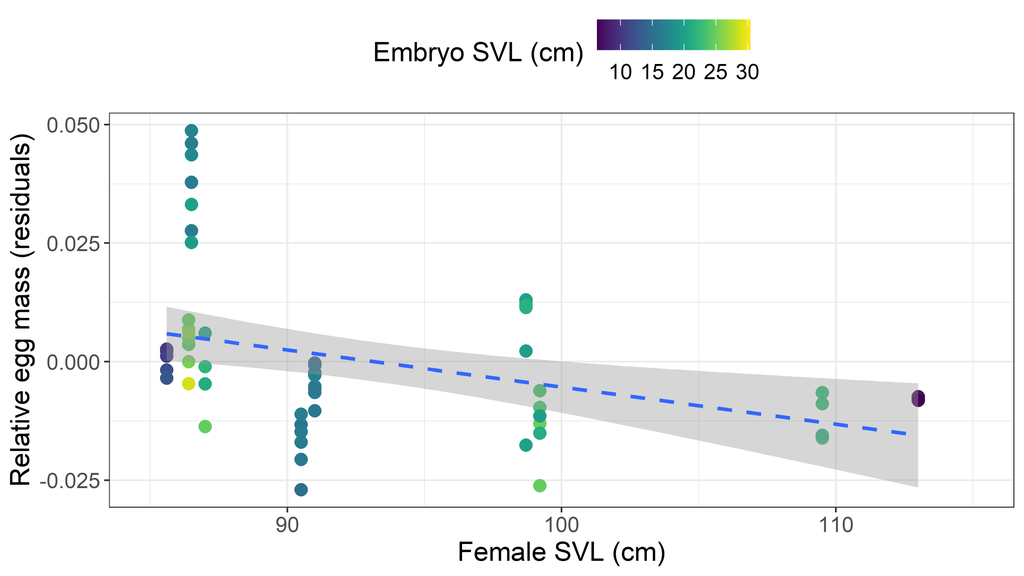

| term | estimate | std.error | statistic | p.value | r.squared |
| --- | --- | --- | --- | --- | --- |
| (Intercept) | 0.0858802 | 0.0260524 | 3.296444 | 0.0017188 | 0.4433341 |
| Female.SVL | -0.0007894 | 0.0002588 | -3.050593 | 0.0035109 | 0.4433341 |
| Embryo.SVL | 0.0023248 | 0.0004171 | 5.573820 | 0.0000008 | 0.4433341 |

The relative egg mass (controlled for embryo development) reduces with female SVL.

## 4.4 Difference in reproductive effort for male and female embryos

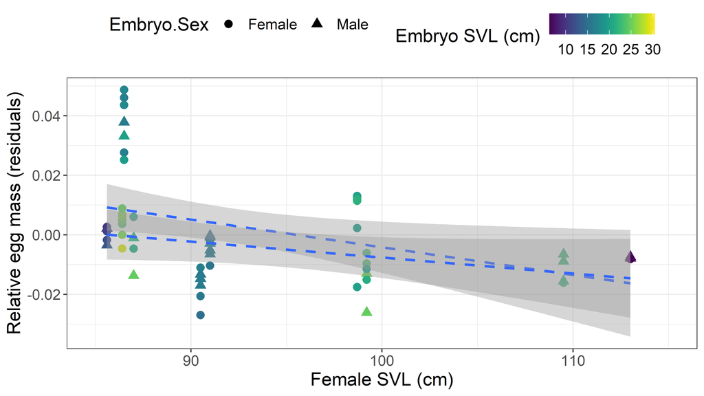

| term | estimate | std.error | statistic | p.value | r.squared |
| --- | --- | --- | --- | --- | --- |
| (Intercept) | 0.0165286 | 0.0090610 | 1.824151 | 0.0735636 | 0.3859103 |
| Embryo.SexMale | -0.0083114 | 0.0045803 | -1.814613 | 0.0750384 | 0.3859103 |
| Embryo.SVL | 0.0022764 | 0.0004455 | 5.109887 | 0.0000042 | 0.3859103 |

# 5 Mortality in bycatch

## 5.1 Overall mortality

| Species | n | N | prop.dead |
| --- | --- | --- | --- |
| Hydrophis curtus | 120 | 282 | 0.4255319 |
| Hydrophis schistosus | 174 | 967 | 0.1799380 |

| estimate1 | estimate2 | statistic | p.value |
| --- | --- | --- | --- |
| 0.4255319 | 0.179938 | 71.81006 | 0 |

## 5.2 Mortality by age class

| Species | Class | n | N | prop.dead |
| --- | --- | --- | --- | --- |
| Hydrophis curtus | Adult | 40 | 62 | 0.6451613 |
| Hydrophis curtus | Juvenile | 41 | 125 | 0.3280000 |
| Hydrophis schistosus | Adult | 138 | 648 | 0.2129630 |
| Hydrophis schistosus | Juvenile | 5 | 105 | 0.0476190 |
| Hydrophis schistosus | Neonate | 3 | 8 | 0.3750000 |

[output not shown]

## 5.3 Mortality by sex

| Species | Sex | n | N | prop.dead |
| --- | --- | --- | --- | --- |
| Hydrophis curtus | Female | 36 | 102 | 0.3529412 |
| Hydrophis curtus | Male | 52 | 110 | 0.4727273 |
| Hydrophis schistosus | Female | 62 | 304 | 0.2039474 |
| Hydrophis schistosus | Male | 72 | 314 | 0.2292994 |

| Species | estimate1 | estimate2 | statistic | p.value |
| --- | --- | --- | --- | --- |
| Hydrophis curtus | 0.3529412 | 0.4727273 | 2.6538718 | 0.1032980 |
| Hydrophis schistosus | 0.2039474 | 0.2292994 | 0.4448479 | 0.5047918 |

## 5.4 Mortality by female reproductive status

| Gravid | n | N | prop.dead |
| --- | --- | --- | --- |
|  | 41 | 151 | 0.2715232 |
| Yes | 16 | 85 | 0.1882353 |

| estimate1 | estimate2 | statistic | p.value |
| --- | --- | --- | --- |
| 0.2715232 | 0.1882353 | 1.629856 | 0.2017229 |